# **Real estate prediction using neural networks, polynomial regression, and ridge regression**

```r
library(reticulate)
use_python("/Users/gregorycrooks/opt/anaconda3/envs/r-reticulate/bin/python")
```

## 0. Project summary

The aim of this project is to analyze real estate parameters and seeing how these affect the house of price unit per area. In parallel to showcasing an exploratory data analysis with comprehensive data visualization, various non-linear Machine Learning techniques were also implemented in the modelling process. Lastly, this project includes an executive summary of results geared towards non-technical audiences.

```python
import matplotlib.pyplot as plt
import numpy as np
import pandas as pd
import seaborn as sns
```

## 1. Introduction / rationale

Our aim consists in analyzing real estate parameters and seeing how these affect the house of price unit per area. The data was collected from Sindian Dist., New Taipei City, in Taiwan. Considering the vast fluctuations in real estate due to covid, it is interesting for investors to gain additional insight as to which factors influence house prices. In this case we want to see how real estate factors could affect the house price of a unit area. This can provide additional value given that real estate data is heavily reliant on the neighborhood’s location, ability to commute, and the nearest shopping center. Linear regression, polynomial regression and neural networks will be used to analyze the dataset and conduct our subsequent analysis.

## 2. Data exploration

```python
df = pd.read_csv('/Users/gregorycrooks/Desktop/Real estate.csv', na_values='?')
df.shape
```

```
## (414, 8)
```

```python
df.describe()
```

```
##                No  ...  Y house price of unit area
## count  414.000000  ...                  414.000000
## mean   207.500000  ...                   37.980193
## std    119.655756  ...                   13.606488
## min      1.000000  ...                    7.600000
## 25%    104.250000  ...                   27.700000
## 50%    207.500000  ...                   38.450000
## 75%    310.750000  ...                   46.600000
## max    414.000000  ...                  117.500000
##
## [8 rows x 8 columns]
```

```python
print(df.isnull().sum())
```

```
## No                                        0
## X1 transaction date                       0
## X2 house age                              0
## X3 distance to the nearest MRT station    0
## X4 number of convenience stores           0
## X5 latitude                               0
## X6 longitude                              0
## Y house price of unit area                0
## dtype: int64
```

### 2.1 Data cleaning

To better analyze our data, we look at the different types (int or float) and notice that no substantial data cleaning will be required given that the data is in the appropriate numeric format. We also verify whether there is any null data within the dataset. In every column, there is a total of 0 Nan which means that no additional wrangling is required. Subsequently, we print a random sample of our dataset to further examine the state of the variables but no particular anomaly is detected.

```python
pd.set_option('display.max_rows', df.shape[0]+1)
del df['No']
print(df.dtypes)
```

```
## X1 transaction date                       float64
## X2 house age                              float64
## X3 distance to the nearest MRT station    float64
## X4 number of convenience stores             int64
## X5 latitude                               float64
## X6 longitude                              float64
## Y house price of unit area                float64
## dtype: object
```

```python
df.sample(10)
```

```
##      X1 transaction date  ...  Y house price of unit area
## 343             2013.000  ...                        46.6
## 34              2012.750  ...                        55.1
## 305             2013.083  ...                        55.0
## 277             2013.417  ...                        27.7
## 19              2012.667  ...                        47.7
## 36              2012.917  ...                        22.9
## 73              2013.167  ...                        20.0
## 139             2012.667  ...                        42.5
## 274             2013.167  ...                        41.0
## 366             2012.750  ...                        24.8
##
## [10 rows x 7 columns]
```

### 2.2 Removing outliers and unnecessary variables

To make sure that the data is accurate we also look for outliers in our analysis and remove variables which are irrelevant.

We notice that there are a lot of outliers for the ’distance to the nearest MRT station variable. However, no particular anomaly is detected from the this variable given that it is not unrealistic for a real estate property to be far awar from a MRT station (even if it is 5-6 km or so). Given their geographical properties we sought to keep longitude and latitude given that they might bring insighful information with regards to our analysis. Indeed, price of houses is heavily dependent on location which might be an insightful indicator for our data.

We have a total of 6 independent variables for our analysis of the house pricing per unit: transaction data, house age, distance to the nearest MRT station, the number of convenience stores, longitude, and latitude.

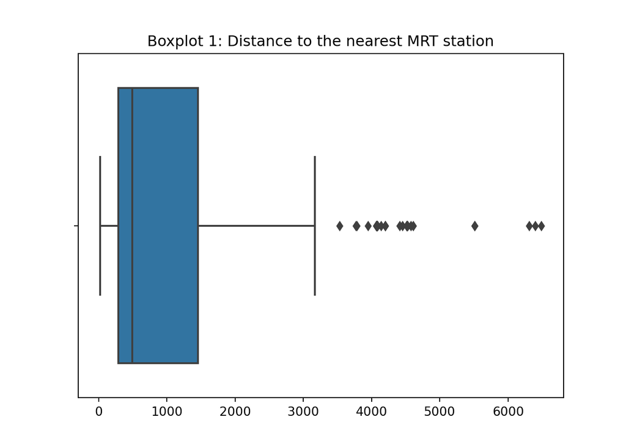

```python
sns.boxplot(x = df['X3 distance to the nearest MRT station']).set(xlabel=''
                                                                  , title = 'Boxplot 1: Distance to the nearest MRT station')
```

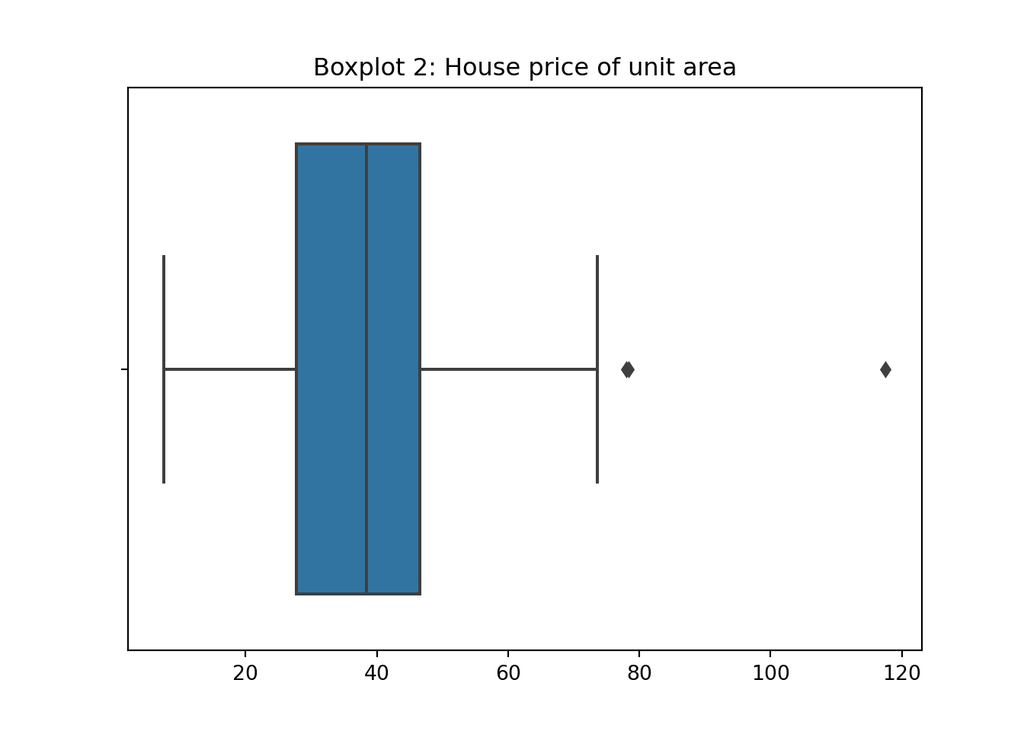

```python
sns.boxplot(x = df['Y house price of unit area']).set(xlabel=''
                                                      , title = 'Boxplot 2: House price of unit area')
```

### 2.3 Relationship between variables

On the account of further statistical analysis, we look at the correlation and multicollinearity between variables by using the heatmat function from the seaborn package. We found a moderately strong positive correlation between the price of unit area and the longitude, the latitude, and the number of convenience stores. We also find a strong negative correlation between the distance to the nearest MRT station and the house of price of unit area. Finally, we find that the distance to the nearest MRT station proves to have a very strong negative correlation with the longitude, and a strong negative correlation with the number of convenience stores as well latitude. Nevertheless, there are some limitations to the heat map. Since latitude and longitude are interrelated geographical measures, their individual values do not provide much information. As such, our scatterplots will display how both of these combined can provide insightful information with regards to geographical clusters.

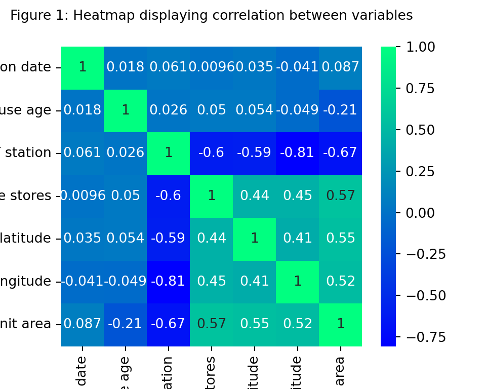

```python
plt.figure(figsize=(5, 4), dpi=100)

ax = sns.heatmap(df.corr(), annot=True,cmap='winter')

ax.set_title('Figure 1: Heatmap displaying correlation between variables',
             pad = 20, fontsize = 10)
```

```python
plt.figure(figsize=(5, 4), dpi=100)

ax = sns.displot(df['Y house price of unit area'],kde=True,bins=20, aspect=2).set(xlabel = 'Price of unit area',
                                                                                 title = "Histogram 1: Normal distribution of dependent variable")
```

[output not shown]

In accordance with the correlation analysis found in the heat map, we interested in further examining variables which show a significant correlation with the house pricing. As such, we create scatterplots to analyze their relationships.

#### Scatterplot 1:

Scatterplot 1 follows the results displayed in the heat map between the price of unit area and the house age per transaction data (the min, 1st quantile, median, 3rd quantile, and max being displayed as interval values in the graph). Although no significant correlation is found in the scatterplot, we can visualise a very mild increase in price if the transaction date is between 2013.4 and 2013.6. While 12 months is not significant to determine this phenomenon, external factors such inflation or changes in the housing market could explain this.

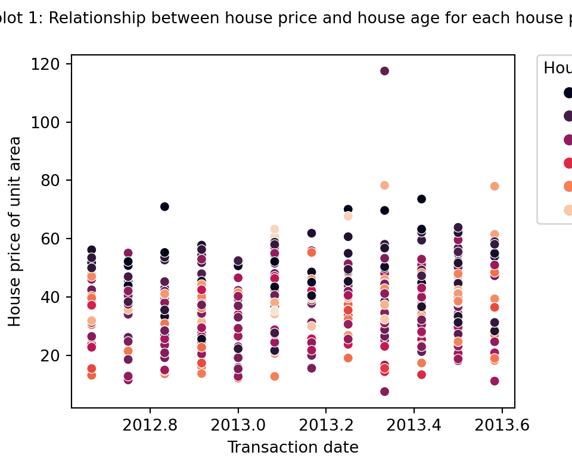

```python
plt.figure(figsize=(5, 4), dpi=100)
ax = sns.scatterplot(data=df, y=df['Y house price of unit area'], x=df['X1 transaction date'] , hue= 'X2 house age', palette="rocket")

ax.set(xlabel = 'Transaction date', ylabel = "House price of unit area")

ax.set_title("Scatterplot 1: Relationship between house price and house age for each house purchased",
             pad = 20, fontsize = 10)

plt.legend(title='House age', bbox_to_anchor=(1.05, 1), loc=2, borderaxespad=0.,
          fontsize = 10)
```

#### Scatterplot 2:

Scatterplot 2 shows the relationship between the house price of unit area and the number of convenience stores, and the distance to the nearest MRT starion. The graph concides with the correlation analysis from the heat map given that the closer distance to the nearest MRT station correlates with more convenience stores and an increase in house price of unit area. More specifically, the graph shows that houses which have a distance of up to 2500 meters to the nearest MRT station will have a significally higher price of unit area and 1 or more convenience stores. Starting from a distance of approximately 2500 meters from the nearest MRT onwards, little to no convenience stores can be found.

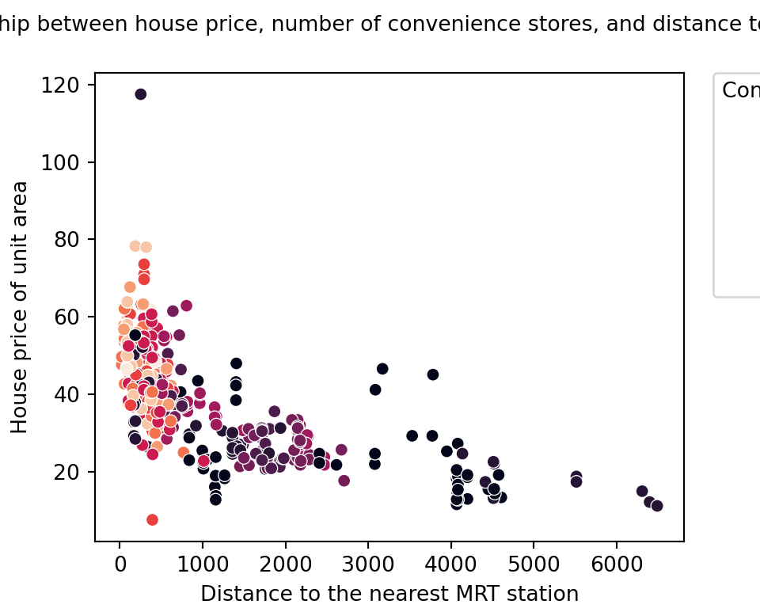

```python
plt.figure(figsize=(5, 4), dpi=100)

ax = sns.scatterplot(data=df, y=df['Y house price of unit area'], x=df['X3 distance to the nearest MRT station']
                , hue= 'X4 number of convenience stores', palette="rocket")

ax.set(xlabel = 'Distance to the nearest MRT station', ylabel = "House price of unit area")

ax.set_title("Scatterplot 2: Relationship between house price, number of convenience stores, and distance to the nearest MRT station",
             pad = 20, fontsize = 10)

plt.legend(title='Convenience stores', bbox_to_anchor=(1.05, 1), loc=2, borderaxespad=0.,
          fontsize = 10)
```

#### Scatterplot 3:

Scatterplot 3 inspects whether the distance between the nearest MRT station concurs with more frequent transaction dates. This graph confirms that it is the case, given that the data for the transaction date (regardless of the date of purchase), is clustered around houses whose distance to the nearest MRT station is at 2500 or less, even though this also concurs with an increase in the house price of unit area. This means that buyers will tend to buy houses which are easier to commute from even if the price is higher.

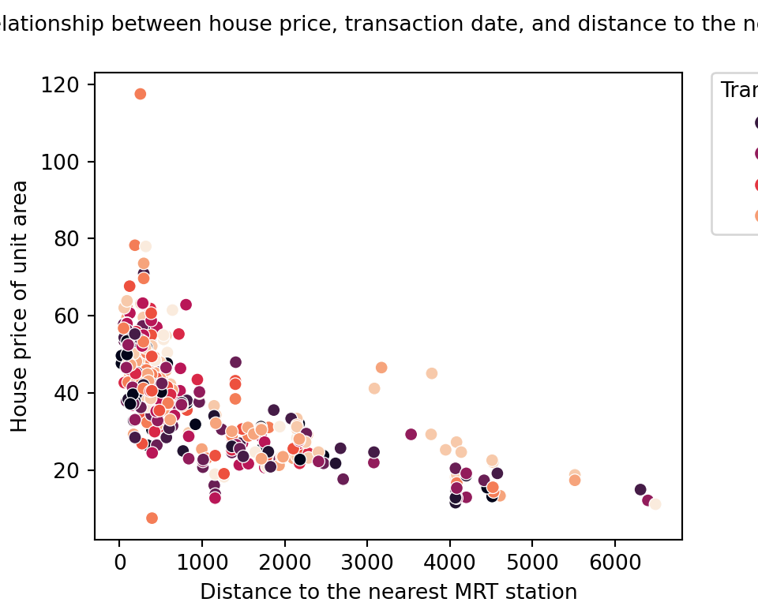

```python
plt.figure(figsize=(5, 4), dpi=100)

ax = sns.scatterplot(data=df, y=df['Y house price of unit area'], x=df['X3 distance to the nearest MRT station'] , hue= 'X1 transaction date', palette="rocket")

ax.set(xlabel = 'Distance to the nearest MRT station', ylabel = "House price of unit area")

ax.set_title("Scatterplot 3: Relationship between house price, transaction date, and distance to the nearest MRT station",
             pad = 20, fontsize = 10)

plt.legend(title='Transaction date', bbox_to_anchor=(1.05, 1), loc=2, borderaxespad=0.,
          fontsize = 10)
```

#### Scatterplot 4:

Scatterplot 4 determines how the location can impact the price. Upon seeing how latitude and longitude interrelate, we noticed a geographical cluster located between the longitude of 121.54 and a latitude between 24.97 / 24.98. The closer to this location, the more common it is to find houses with a house price of unit area ranging between 60 to 100. On the outskirts of this geographical concentration, the price of houses depreciates. This means that real estate properties are more valued in this neighborhood. This also indicates that this neighborhood is central within the Sindian district.

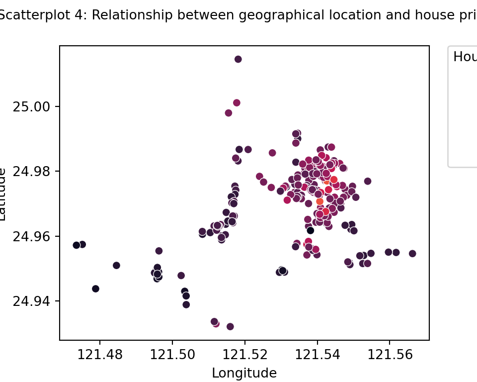

```python
plt.figure(figsize=(5, 4), dpi=100)

ax = sns.scatterplot(data=df, y=df['X5 latitude'], x=df['X6 longitude'] , hue= 'Y house price of unit area', palette="rocket")

ax.set(xlabel = 'Longitude', ylabel = "Latitude")

ax.set_title("Scatterplot 4: Relationship between geographical location and house price",
             pad = 20, fontsize = 10)

plt.legend(title='House price of unit area', bbox_to_anchor=(1.05, 1), loc=2, borderaxespad=0.,
          fontsize = 10)
```

#### Scatterplot 5:

In scatterplot 5, we analyzed the relationship between the frequency of transactions and location. Data shows that houses which are the most commonly purchased are located in the neighborhood with the highest price of unit area. This further supports our findings from scatterplot 4 with regards to this neighborhood being a central location. Indeed, the vast majority of buyers want to buy houses located in this neighborhood, even if the price tends to be higher.

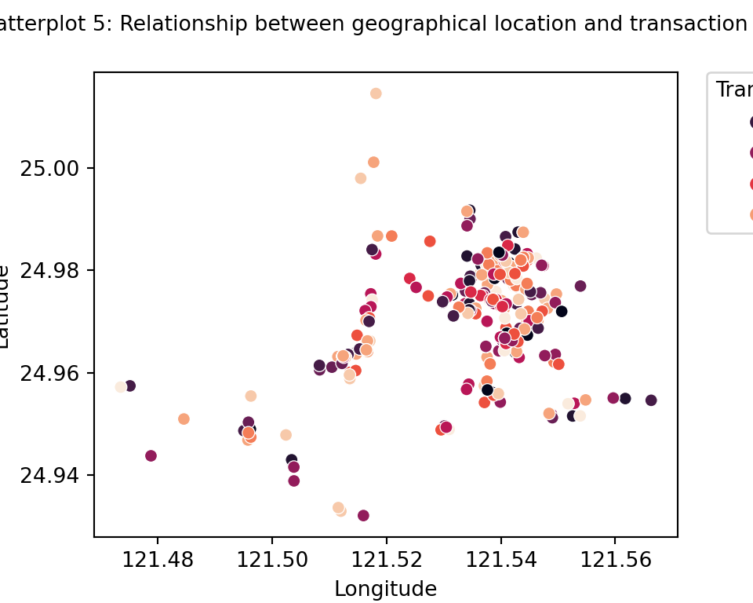

```python
plt.figure(figsize=(5, 4), dpi=100)
ax = sns.scatterplot(data=df, y=df['X5 latitude'], x=df['X6 longitude'] , hue= 'X1 transaction date', palette="rocket")

ax.set(xlabel = 'Longitude', ylabel = "Latitude")

ax.set_title("Scatterplot 5: Relationship between geographical location and transaction date",
             pad = 20, fontsize = 10)

plt.legend(title='Transaction date', bbox_to_anchor=(1.05, 1), loc=2, borderaxespad=0.,
          fontsize = 10)
```

#### Scatterplot 6:

Scatterplot 6 shows the number of convenience stores in different neighborhoods in the Sindian Dist of New Taipei City, Taiwan. In concordance with scatterplots 4 and 5, this graph also indicates that the location which has the highest number of house purchases, the higher price of unit area, also has the highest number of convenience stores. Neighborhood on the outskirts of the city center will tend to have 0 convenience stores and are therefore less in demand than those with more convenience stores.

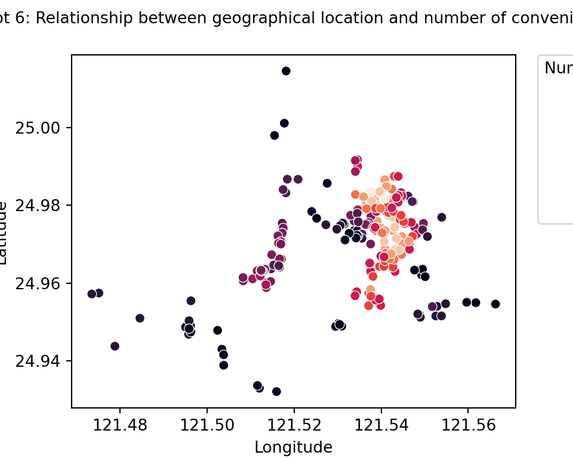

```python
plt.figure(figsize=(5, 4), dpi=100)

ax = sns.scatterplot(data=df, y=df['X5 latitude'], x=df['X6 longitude'] , hue= 'X4 number of convenience stores', palette="rocket")

ax.set(xlabel = 'Longitude', ylabel = "Latitude")

ax.set_title("Scatterplot 6: Relationship between geographical location and number of convenience stores",
             pad = 20, fontsize = 10)

plt.legend(title='Number of convenience stores', bbox_to_anchor=(1.05, 1), loc=2, borderaxespad=0.,
          fontsize = 10)
```

#### Scatterplot 7:

Scatterplot 7 shows that the city center concentrates most of the oldest houses. While there are houses which have been built very recently in the same neighborhood, the median for house age is approximately 16. That is, out of the 40 year old houses, a much higher proportion of them is centered around this location, and it is much more common to find houses which have been built in the last 16 years outside of the city center. This implies that it is a residential neighborhood in which most of the residents are families.

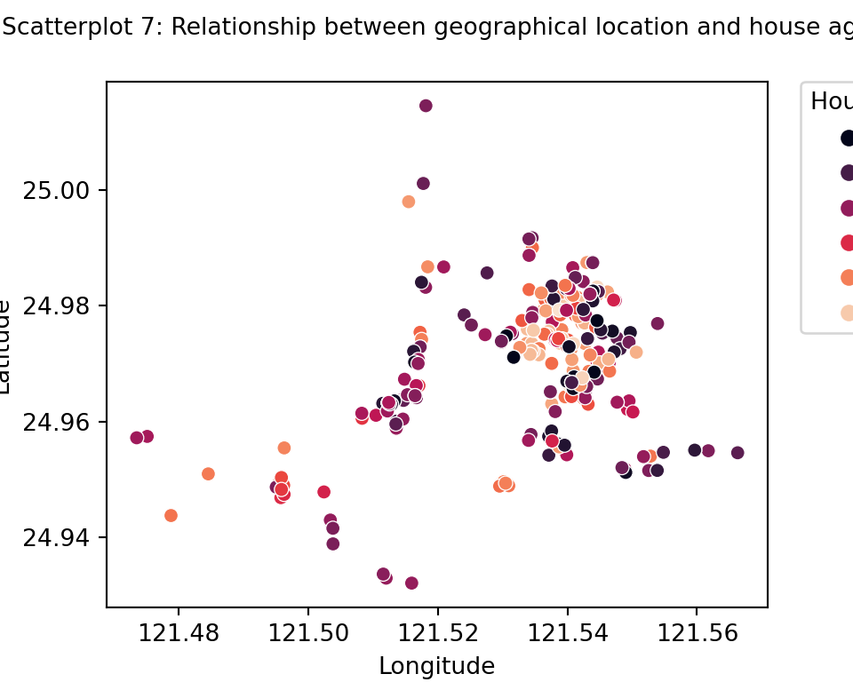

```python
plt.figure(figsize=(5, 4), dpi=100)

ax = sns.scatterplot(data=df, y=df['X5 latitude'], x=df['X6 longitude'] , hue= 'X2 house age', palette="rocket")

ax.set(xlabel = 'Longitude', ylabel = "Latitude")

ax.set_title("Scatterplot 7: Relationship between geographical location and house age",
             pad = 20, fontsize = 10)

plt.legend(title='House age', bbox_to_anchor=(1.05, 1), loc=2, borderaxespad=0.,
          fontsize = 10)
```

#### Scatterplot 8:

The 8th scatterplot displays the distance to the nearest MRT station for different geographical locations. The graph very strongly indicates how most of the houses in the city center are closer to the nearest MRT station. This also explains how the demand and price of unit area is higher, given that it is easier to commute to and from this neighborhood. Indeed, the vast majority of houses are 1000 meters or less to a MRT station, whereas houses outside of the central location will increasingly stray away from the nearest station. For instance, residents located in the area whose longitude is 121.48 and latitude is 24.96 are 6 km away from the nearest station. This means that they will take much longer to commute.

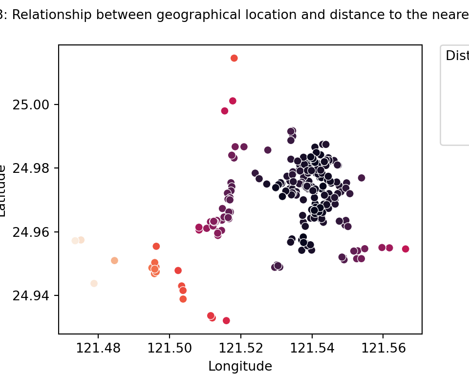

```python
plt.figure(figsize=(5, 4), dpi=100)

ax = sns.scatterplot(data=df, y=df['X5 latitude'], x=df['X6 longitude'], hue= 'X3 distance to the nearest MRT station', palette="rocket" )

ax.set(xlabel = 'Longitude', ylabel = "Latitude")

ax.set_title("Scatterplot 8: Relationship between geographical location and distance to the nearest MRT station",
             pad = 20, fontsize = 10)

plt.legend(title='Distance to the nearest MRT station', bbox_to_anchor=(1.05, 1), loc=2, borderaxespad=0.,
          fontsize = 10)
```

Lastly, it is necessary to point issues of collinearity. Results strongly suggest that the closer to a MRT station, the more the number of convenience stores can be found. Out of both explanatory variables, we notice that the distance to the nearest MRT station has a stronger relationship. As such, we did not include the number of convenience stores in our resampling. We did not include latitude and longitude either given that they are storngly interrelated. There are now 3 explanatory variables: transaction date, house age, and distance to the nearest MRT station.

## 3. Data modelling

### 3.1 Data split

Our first step to detect overfitting is to split the data into a train and testing set (⅔ to ⅓ ) which we then pre-processed by standardizing features, removing the mean, and subsequently scaled to unit variance. We also set a seed to ensure reproducibility. Moreover, to assess the robustness of our model, we used the MAE (mean absolute error) as a metric. The MAE looks at the difference between the prediction of an observation and the true value of that observation.

```python
from scipy import stats

df_changed = df.drop(columns = ["X4 number of convenience stores",
                              "X5 latitude",
                              "X6 longitude",
                              'Y house price of unit area'])
X_values = df_changed.values
X_values
```

```
## array([[2012.917  ,   32.     ,   84.87882],
##        [2012.917  ,   19.5    ,  306.5947 ],
##        [2013.583  ,   13.3    ,  561.9845 ],
##        ...,
##        [2013.25   ,   18.8    ,  390.9696 ],
##        [2013.     ,    8.1    ,  104.8101 ],
##        [2013.5    ,    6.5    ,   90.45606]])
```

```python
y = df['Y house price of unit area'].values
```

```python
from sklearn.model_selection import train_test_split
X_train_raw, X_test_raw, y_train, y_test = train_test_split(X_values, y, test_size=0.33, random_state=2022)
```

```python
# for linear regression the data needs to be standard scaled
from sklearn.preprocessing import StandardScaler
SS = StandardScaler()
SS.fit(X_train_raw)
```

```
## StandardScaler()
```

```python
X_train = SS.transform(X_train_raw)
X_test = SS.transform(X_test_raw)
```

### 3.2 Initial linear regression

Firstly, we ran standard linear regression (i.e. degrees 1 polynomial). This was to set a baseline to then compare with polynomial regress. We first and foremost notice that there is no substantial overfitting in our results given the little difference between our training and testing set. We find that the baseline absolute error with standard linear regression is about 7.4.

```python
from sklearn.linear_model import LinearRegression

model = LinearRegression(fit_intercept=True)
model.fit(X_train, y_train)
```

```
## LinearRegression()
```

```python
def mae(predictions, y_test):
    return np.mean(np.abs(predictions-y_test))
```

```python
LR_train_mae = mae(model.predict(X_train), y_train)
LR_test_mae = mae(model.predict(X_test), y_test)
```

```python
print("LR train mae: {}".format(LR_train_mae))
```

```
## LR train mae: 6.521571756338549
```

```python
print("LR test mae: {}".format(LR_test_mae))
```

```
## LR test mae: 7.384596893522332
```

### 3.3 Poly features of best fit - regression

```python
from sklearn.linear_model import Ridge
from sklearn.preprocessing import PolynomialFeatures

n_values = range(1, 8)

train_errors = []
test_errors = []
for n in n_values:
    poly = PolynomialFeatures(degree=n, interaction_only = False)
    X_poly_train = poly.fit_transform(X_train)
    X_poly_test  = poly.transform(X_test)

    model = LinearRegression(fit_intercept=True)
    model.fit(X_poly_train, y_train)
    LR_poly_train_mae = mae(model.predict(X_poly_train), y_train)
    LR_poly_test_mae = mae(model.predict(X_poly_test), y_test)

    train_errors.append(LR_poly_train_mae)
    test_errors.append(LR_poly_test_mae)
    print("N {}".format(n))
    print("LR train mae: {}".format(LR_poly_train_mae))
    print("LR test mae: {}".format(LR_poly_test_mae))
    print("")
```

```
## LinearRegression()
## N 1
## LR train mae: 6.521571756338549
## LR test mae: 7.384596893522332
##
## LinearRegression()
## N 2
## LR train mae: 5.4197054384186245
## LR test mae: 6.142148548896064
##
## LinearRegression()
## N 3
## LR train mae: 5.257224893526242
## LR test mae: 5.746138475538864
##
## LinearRegression()
## N 4
## LR train mae: 5.078420090412917
## LR test mae: 6.072010237420974
##
## LinearRegression()
## N 5
## LR train mae: 4.593417187102522
## LR test mae: 7.629315126992115
##
## LinearRegression()
## N 6
## LR train mae: 10.218626607626353
## LR test mae: 26.1658203125
##
## LinearRegression()
## N 7
## LR train mae: 9.570644954309566
## LR test mae: 42.298952511975365
```

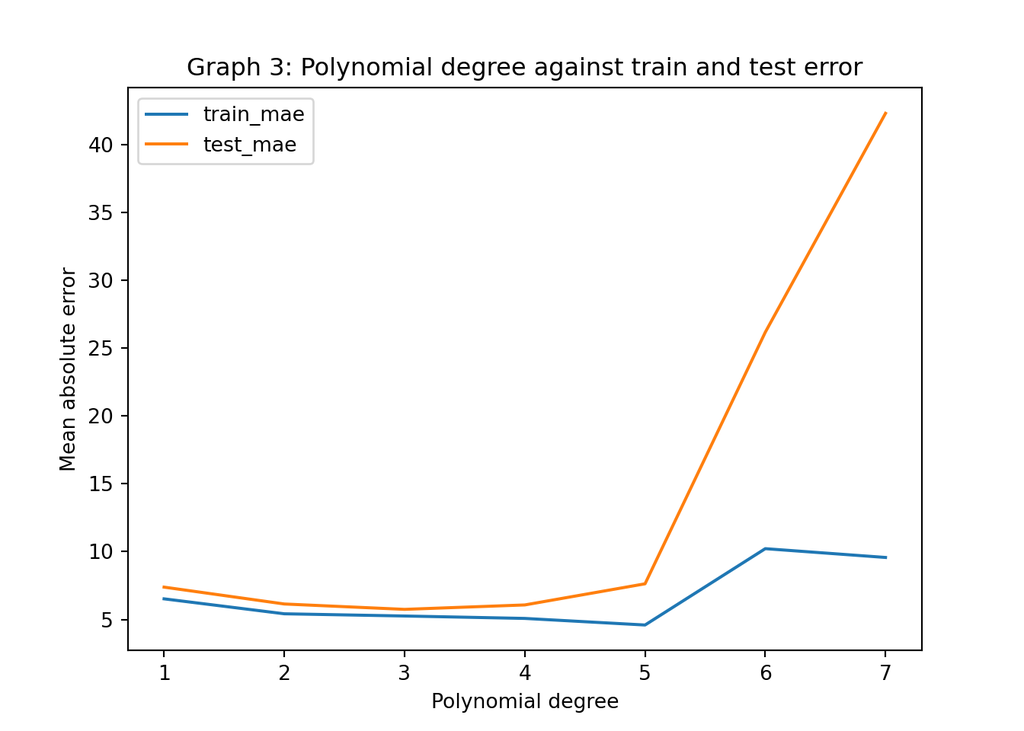

```python
plt.figure()
plt.title("Graph 3: Polynomial degree against train and test error")
plt.plot(n_values, train_errors, label="train_mae")
plt.plot(n_values, test_errors, label="test_mae")
plt.xlabel("Polynomial degree")
plt.ylabel("Mean absolute error")
plt.legend()
```

### 3.4 Ridge regression

```python
from sklearn.linear_model import Ridge

for a in np.linspace(0.01, 0.1, 10):
    model = Ridge(alpha=a)
    model.fit(X_train, y_train)
    LR_train_mae = mae(model.predict(X_train), y_train)
    LR_test_mae = mae(model.predict(X_test), y_test)

    print("alpha {}".format(a))
    print("Ridge train mae: {}".format(LR_train_mae))
    print("Ridge test mae: {}".format(LR_test_mae))
    print("")
```

```
## Ridge(alpha=0.01)
## alpha 0.01
## Ridge train mae: 6.521596612634986
## Ridge test mae: 7.384567435651112
##
## Ridge(alpha=0.020000000000000004)
## alpha 0.020000000000000004
## Ridge train mae: 6.52162146722416
## Ridge test mae: 7.384537979824193
##
## Ridge(alpha=0.030000000000000006)
## alpha 0.030000000000000006
## Ridge train mae: 6.521646320106251
## Ridge test mae: 7.38450852604136
##
## Ridge(alpha=0.04000000000000001)
## alpha 0.04000000000000001
## Ridge train mae: 6.52167117128143
## Ridge test mae: 7.384479074302395
##
## Ridge(alpha=0.05000000000000001)
## alpha 0.05000000000000001
## Ridge train mae: 6.5216960207498795
## Ridge test mae: 7.384449624607088
##
## Ridge(alpha=0.06000000000000001)
## alpha 0.06000000000000001
## Ridge train mae: 6.521720868511773
## Ridge test mae: 7.3844201769552145
##
## Ridge(alpha=0.07)
## alpha 0.07
## Ridge train mae: 6.521745714567286
## Ridge test mae: 7.384390731346564
##
## Ridge(alpha=0.08)
## alpha 0.08
## Ridge train mae: 6.521770558916597
## Ridge test mae: 7.38436128778092
##
## Ridge(alpha=0.09000000000000001)
## alpha 0.09000000000000001
## Ridge train mae: 6.521795401559881
## Ridge test mae: 7.384331846258067
##
## Ridge(alpha=0.1)
## alpha 0.1
## Ridge train mae: 6.521820242497316
## Ridge test mae: 7.3843024067777865
```

### 3.5 Poly features - ridge regression

Ridge regression shrinks the regression coefficients, so that variables, with minor contribution to the outcome, have their coefficients close to zero. The shrinkage of the coefficients is achieved by penalizing the regression model with a penalty term.

```python
for n in range(1, 8):
    poly = PolynomialFeatures(degree=n, interaction_only = False)
    X_poly_train = poly.fit_transform(X_train)
    X_poly_test  = poly.transform(X_test)



    for a in np.linspace(0.01, 0.1, 10):
        model = Ridge(alpha=a)
        model.fit(X_poly_train, y_train)
        LR_train_mae = mae(model.predict(X_poly_train), y_train)
        LR_test_mae = mae(model.predict(X_poly_test), y_test)

        print("n: {}, alpha {}".format(n, a))
        print("Ridge train mae: {}".format(LR_train_mae))
        print("Ridge test mae: {}".format(LR_test_mae))
        print("")
```

```
## Ridge(alpha=0.01)
## n: 1, alpha 0.01
## Ridge train mae: 6.521596612634987
## Ridge test mae: 7.384567435651111
##
## Ridge(alpha=0.020000000000000004)
## n: 1, alpha 0.020000000000000004
## Ridge train mae: 6.52162146722416
## Ridge test mae: 7.384537979824193
##
## Ridge(alpha=0.030000000000000006)
## n: 1, alpha 0.030000000000000006
## Ridge train mae: 6.521646320106251
## Ridge test mae: 7.38450852604136
##
## Ridge(alpha=0.04000000000000001)
## n: 1, alpha 0.04000000000000001
## Ridge train mae: 6.52167117128143
## Ridge test mae: 7.384479074302395
##
## Ridge(alpha=0.05000000000000001)
## n: 1, alpha 0.05000000000000001
## Ridge train mae: 6.5216960207498795
## Ridge test mae: 7.384449624607087
##
## Ridge(alpha=0.06000000000000001)
## n: 1, alpha 0.06000000000000001
## Ridge train mae: 6.521720868511773
## Ridge test mae: 7.384420176955215
##
## Ridge(alpha=0.07)
## n: 1, alpha 0.07
## Ridge train mae: 6.5217457145672855
## Ridge test mae: 7.384390731346564
##
## Ridge(alpha=0.08)
## n: 1, alpha 0.08
## Ridge train mae: 6.521770558916597
## Ridge test mae: 7.384361287780919
##
```

[output cut: 294 more lines]

```
##
## Ridge(alpha=0.08)
## n: 7, alpha 0.08
## Ridge train mae: 3.6797223955442577
## Ridge test mae: 24.149637403823164
##
## Ridge(alpha=0.09000000000000001)
## n: 7, alpha 0.09000000000000001
## Ridge train mae: 3.686285498881524
## Ridge test mae: 23.668271292252104
##
## Ridge(alpha=0.1)
## n: 7, alpha 0.1
## Ridge train mae: 3.6924817648873645
## Ridge test mae: 23.244456914649188
```

```python
n=3
poly = PolynomialFeatures(degree=n, interaction_only = False)
X_poly_train = poly.fit_transform(X_train)
X_poly_test  = poly.transform(X_test)



train_mae = []
test_mae  = []
a_values = np.linspace(0.01, 0.1, 10)
for a in a_values:
    model = Ridge(alpha=a)
    model.fit(X_poly_train, y_train)
    LR_train_mae = mae(model.predict(X_poly_train), y_train)
    LR_test_mae = mae(model.predict(X_poly_test), y_test)

    train_mae.append(LR_train_mae)
    test_mae.append(LR_test_mae)

    #print("n: {}, alpha {}".format(n, a))
    #print("Ridge train mae: {}".format(LR_train_mae))
    #print("Ridge test mae: {}".format(LR_test_mae))
    #print("")
```

```
## Ridge(alpha=0.01)
## Ridge(alpha=0.020000000000000004)
## Ridge(alpha=0.030000000000000006)
## Ridge(alpha=0.04000000000000001)
## Ridge(alpha=0.05000000000000001)
## Ridge(alpha=0.06000000000000001)
## Ridge(alpha=0.07)
## Ridge(alpha=0.08)
## Ridge(alpha=0.09000000000000001)
## Ridge(alpha=0.1)
```

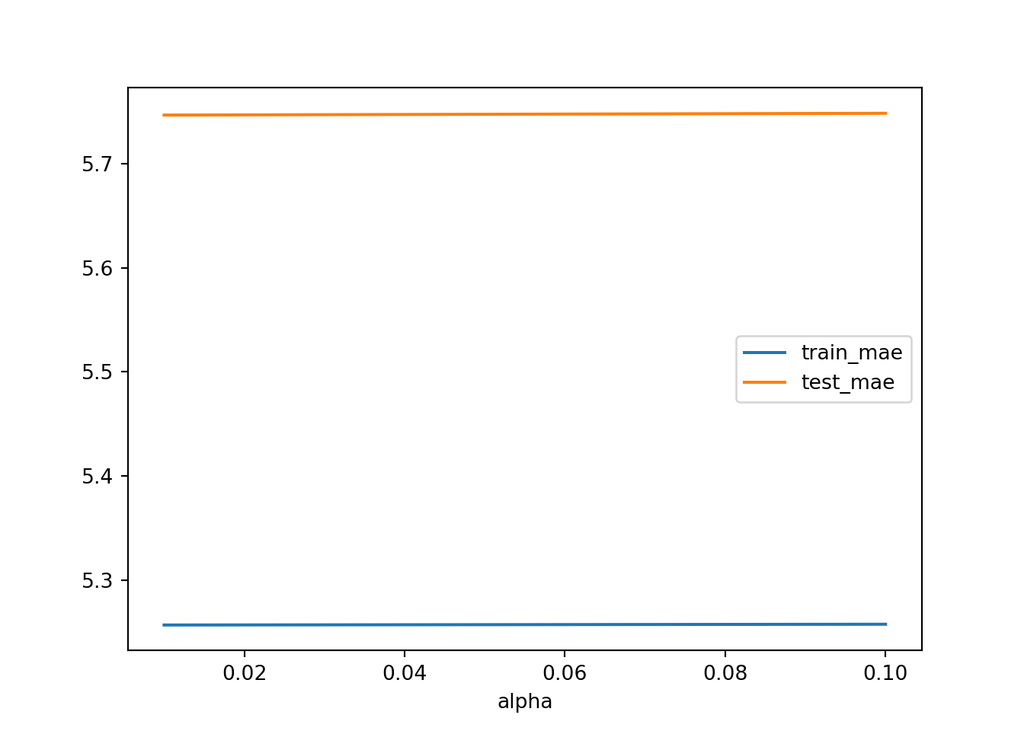

```python
plt.plot(a_values, train_mae, label="train_mae")
plt.plot(a_values, test_mae, label="test_mae")
plt.xlabel("alpha")
plt.legend()
```

Results from ridge regression show that the tuning parameter does not make a sustantial difference when using the polynomial of best fit. Indeed, ridge is effective when there is a high number of predictors and high collinearity. In this case, the highly collinear variables have been removed in the EDA, leaving only 3 predictors for out modelling process. As such, we will use neural networks to further reinforce our model.

### 3.6 Neural networks

Neural networks are extremely good at finding patterns in complex data such as images or sound. Neural networks create their own non-linear features through the process of backpropagation. Whilst neural networks are known for working well on complex homogenous data (images, sound, video), we are interested to see if they would work on a task such as this (tabular data).

```python
import keras
```

```python
class Mul(keras.layers.Layer):
    def __init__(self, val):
        self.const = val
    def call(self, inputs):
        return inputs*self.const
```

We trial two model architectures: architecture one has two hidden layers of 10 and 5 nodes; architecture two has one hidden layer of 3 nodes. Each architecture was trained for 100 epochs, using an ADAM optimizer, and a loss function of mean squared error (however we continue to validate using MAE).

```python
model = keras.models.Sequential()
model.add(keras.layers.Dense(10, input_dim=3, activation="relu"))
model.add(keras.layers.Dense(5, activation="relu"))
model.add(keras.layers.Dense(1, activation="relu"))
#model.add(keras.layers.Lambda(lambda x:x*78.3))

# the softmax puts the output of the network between 0 and 1.
# We need to multiple this by the max expected value to ensure the network outputs in the desired range

model.compile(loss="mse", optimizer="adam", metrics=["mae"])

history = model.fit(X_train, y_train, epochs=100, batch_size=1, validation_data=(X_test, y_test))
```

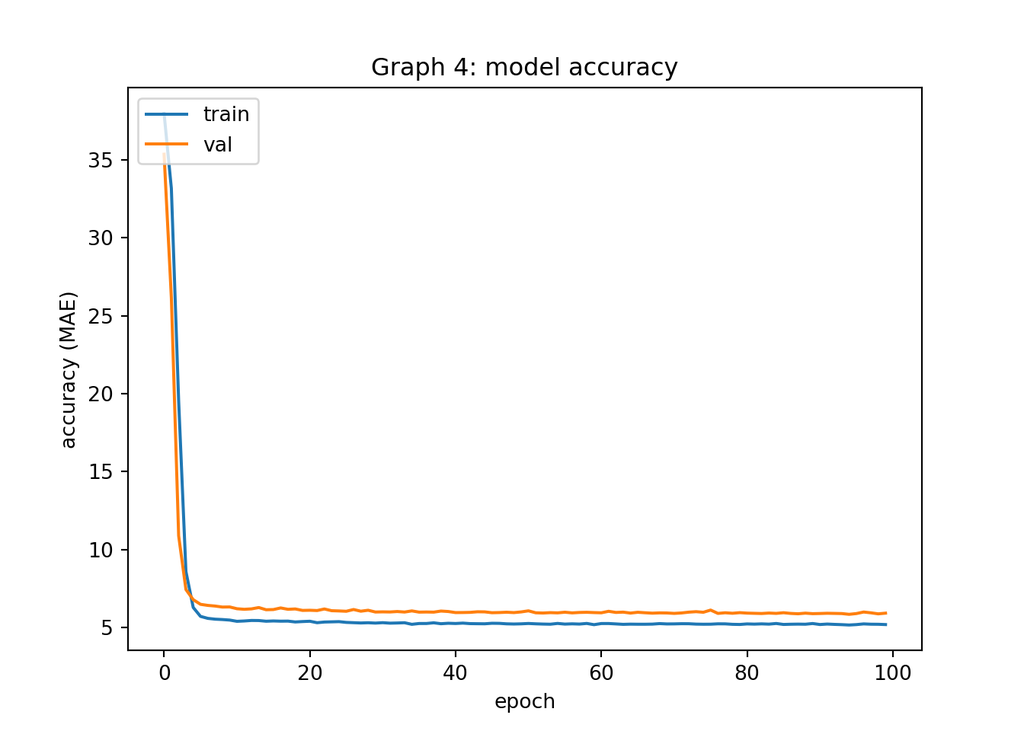

```python
plt.plot(history.history['mae'])
plt.plot(history.history['val_mae'])
plt.title('Graph 4: model accuracy')
plt.ylabel('accuracy (MAE)')
plt.xlabel('epoch')
plt.legend(['train', 'val'], loc='upper left')
plt.show()
```

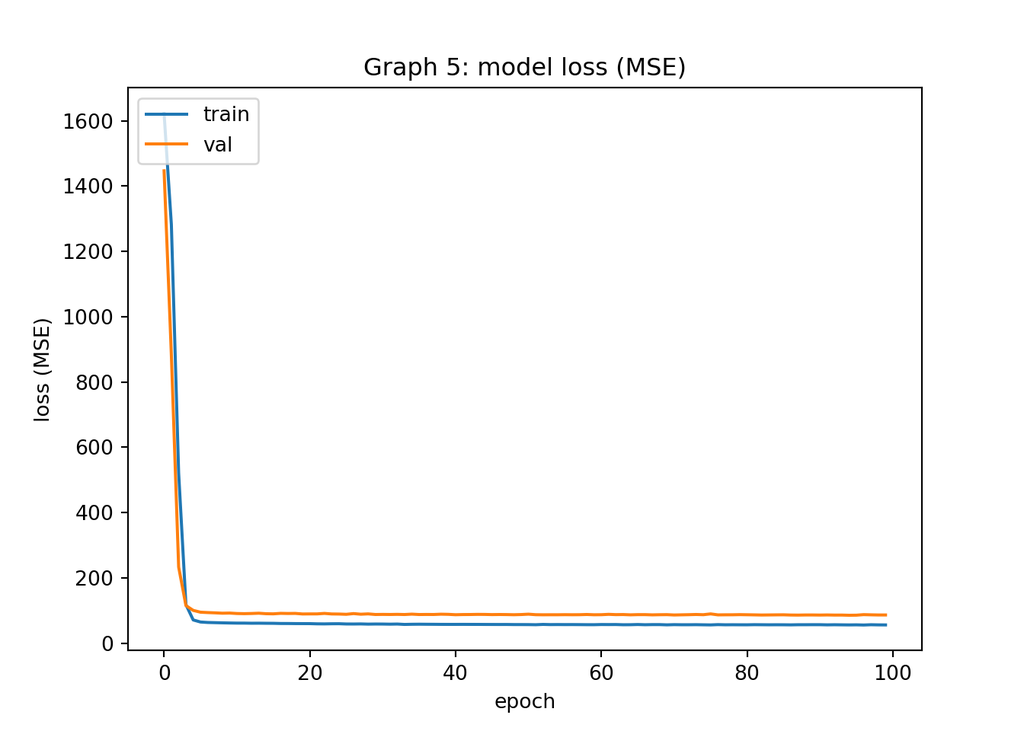

```python
plt.figure()
plt.plot(history.history['loss'])
plt.plot(history.history['val_loss'])
plt.title('Graph 5: model loss (MSE)')
plt.ylabel('loss (MSE)')
plt.xlabel('epoch')
plt.legend(['train', 'val'], loc='upper left')
plt.show()
```

```python
# smaller network

model = keras.models.Sequential()
model.add(keras.layers.Dense(3, input_dim=3, activation="relu"))
model.add(keras.layers.Dense(1, activation="relu"))

# the softmax puts the output of the network between 0 and 1.
# We need to multiple this by the max expected value to ensure the network outputs in the desired range

model.compile(loss="mse", optimizer="adam", metrics=["mae"])

history = model.fit(X_train, y_train, epochs=100, batch_size=1, validation_data=(X_test, y_test))
```

#### Architecture 2: 1 hidden layer and 3 nodes

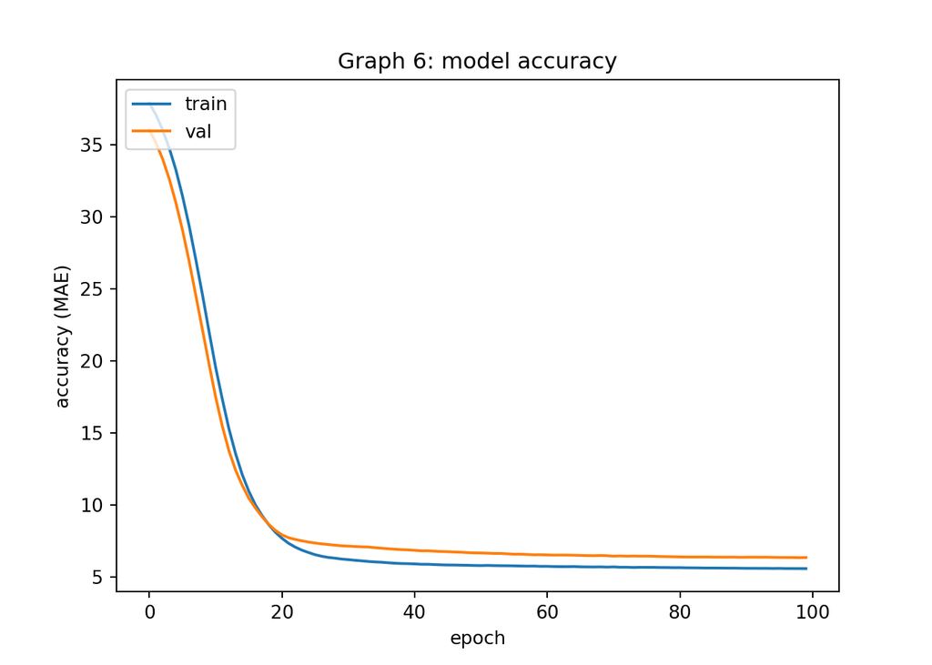

```python
plt.plot(history.history['mae'])
plt.plot(history.history['val_mae'])
plt.title('Graph 6: model accuracy')
plt.ylabel('accuracy (MAE)')
plt.xlabel('epoch')
plt.legend(['train', 'val'], loc='upper left')
plt.show()
```

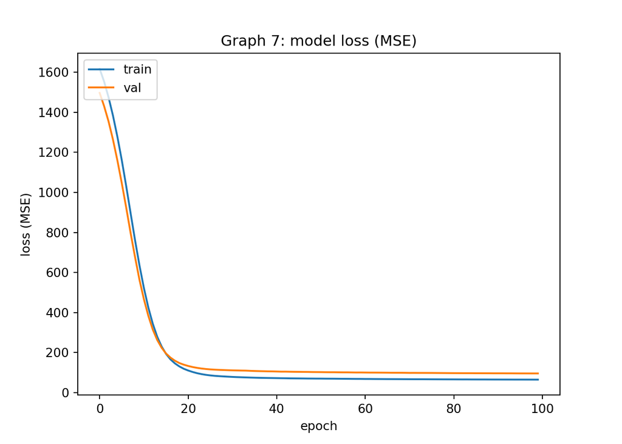

```python
plt.figure()
plt.plot(history.history['loss'])
plt.plot(history.history['val_loss'])
plt.title('Graph 7: model loss (MSE)')
plt.ylabel('loss (MSE)')
plt.xlabel('epoch')
plt.legend(['train', 'val'], loc='upper left')
plt.show()
```

## 4. Conclusion and discussion

Despite the neural network getting the same result as the polynomial of the 3rd degree, the polynomial linear regression is far more favorable in this case. Occam’s razor states that everything should be as simple as possible, and the latter is far more simple (Domingo, 1999). Regression techniques are also far faster to compute (although both take the order of seconds for a dataset of this size). Linear regression has a major advantage in that the weights are interpretable, i.e. one can look at the average change in house price per unit change in a feature. This means it can be easily described as a non-expert. However, this advantage is lost when the polynomial features are used (one cannot expect a non-expert to understand polynomial features). This means there is a tradeoff between model accuracy and model simplicity, and the best course of action depends on the specific use case. Therefore if we were advising an estate agent who was looking to obtain a tool for predicting house prices, we would advise that they use a linear regression technique, as the MAE is very low, and it uses simple, interpretable features.

## 5. Executive summary

The problem that we wished to address was finding which were the most important factors for house price in the Sindian Dist of Taiwan, and using these factors to predict the house price per unit area. We hope this tool could be used by investors. This also allows us to see which section of the district is the most demanded by local buyers. To do so, we looked at the significance of house age, ability to commute, and location in relation to the house price. We noticed that there was a central location in the city which concentrates the most buyers, the highest prices, the majority of the MRT stations, the oldest houses, and most of the purchases. As such, we can conclude that this area is principally a residential area consisting mostly of families. It is subsequently the most interesting region to invest in with the district.

Subsequently, we created a model which predicts the house price per unit area by multiplying each feature by a number and adding a separate number:

Distance to MRT * w1 + Transaction date * w2 + House age * w3 + w4 = Predict price unit area.

Investors can use this simple equation and numbers w1-w4 to calculate an accurate prediction of price per unit area. This equation has an average error of 7.4 (difference in price per unit area). Multiplying this error by the number of units areas in the property will give a range for the average error. The investors can use this error to decide if the investment is worth the risk.